# Investigating the 1986 Space Shuttle Challenger Accident

Jonathan Phan, Priya Reddy, Spencer Zezulka

# Introduction

## Research question: Predict O-ring performance under the Challenger launch conditions and assess Challenger Report analysis on the effects of temperature on O-ring performance.

# Data

## Description

The data that we are working with is from is from the 23 pre-accident Challenger launches. The data collected includes information on the flight number, temperature (F), pressure (PSI), number of O-rings that failed, and the total number of O-rings on the flight. Each flight had 6 O-rings and thus could have had between 0 and 6 O-ring failures. To better understand the effect the feature of the data set (specifically temperature) had on the O-ring failures we are using a logistic regression model to estimate the probability that an O-ring will fail. In order to use this model we must assume the independece of each O-ring for each launch. The assumption of independence for each O-ring is necessary because logistic regression assumes that each trial (flight in this instance) is independent from each other. Logistic regression also uses the binomial distribution to model the probability success and/or failure. Some potential violations of this assumption of independence is that the failure of one O-ring may be due to another O-ring failing. There may also be other dependency problems, perhaps relating to the fact that each launch’s O-rings may have gone through the same installation or manufacturing processes.

## Key Features

Our variables of interest for this analysis are temperature and pressure.

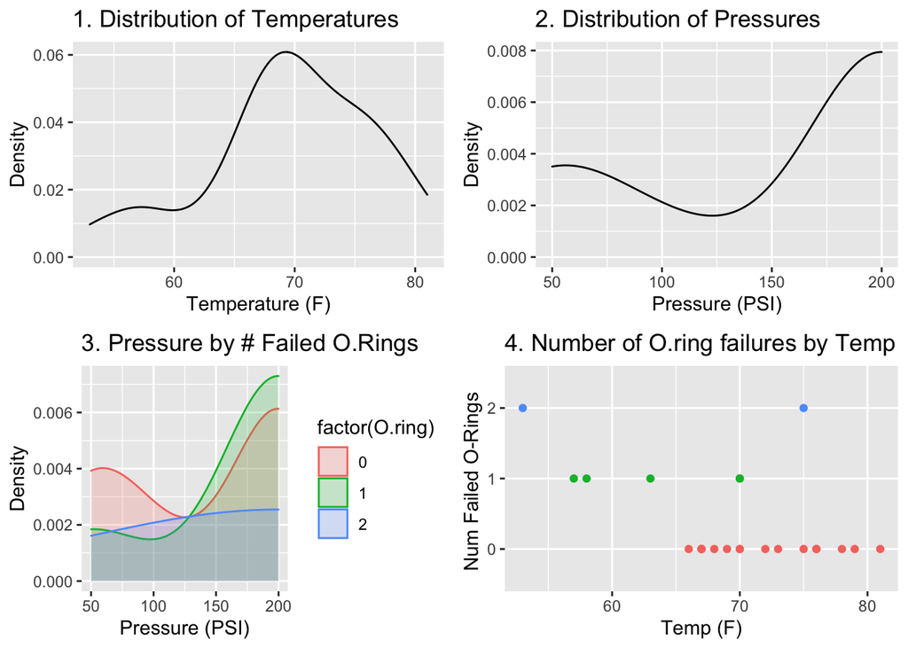

```r
#Distribtion of temp
O.ring.temp <- data %>%
  ggplot(aes(x = Temp)) +
  geom_density(aes(y  = ..density..))+
  xlab("Temperature (F)")+
  ylab("Density")+
  ggtitle("1. Distribution of Temperatures")

#Distribtion of pressure
O.ring.pressure <- data %>%
  ggplot(aes(x = Pressure)) +
  geom_density(aes(y  = ..density..))+
  xlab("Pressure (PSI)")+
  ylab("Density")+
  ggtitle("2. Distribution of Pressures")

#Distribution of pressure grouped by O.ring
O.ring.pressure.fail <- data %>%
  ggplot(aes(x = Pressure)) +
  geom_density(aes(y  = ..density.., color = factor(O.ring), fill = factor(O.ring)), alpha = 0.2)+
  xlab("Pressure (PSI)")+
  ylab("Density")+
  ggtitle("3. Pressure by # Failed O.Rings")

#Number of O.ring failures Across Different Temperatures
O.rings <- data %>%
  ggplot(aes(x = Temp, y= factor(O.ring))) +
  geom_point(aes(color=factor(O.ring)))+
  theme(legend.position = "none")+
  ylab("Num Failed O-Rings ")+
  xlab("Temp (F)")+
  ggtitle("4. Number of O.ring failures by Temp")

grid.arrange(O.ring.temp, O.ring.pressure,O.ring.pressure.fail,O.rings, ncol=2, nrow=2)
```

Based on the plots above we can see in plot 1 that the distribution of the temperatures of the launches is roughly normal and in plot 2 that the distribution of the pressures is bi-modal. Plot 2 indicates that most launches occur at a higher pressure, but the plot 3, the distribution of pressures by number of failures, shows that O-ring failures occur both at ends of the pressure range. Further statistical testing later in this paper will show this lack of significance more clearly. Plot 4, the scatter plot of temperature vs the amount of failed O-rings shows that there are only 2 instances where 2 O-rings have failed in a given launch. The lack of more data points where 2 O-rings have failed may affect our later analysis. But overall, the fourth plot seems to show a negative relationship between temperature and number of O-ring failures, it appears that fewer O-ring failures occur at higher temperatures.

# Analysis

## Reproducing Previous Analysis

To evaluate the previous Challenger analysis, we first begin by constructing our logistic regression model using `Temp` and `Pressure` as our explanatory variables. Our initial model thus is in the form
$$logit(\hat{\pi}) =
\beta_{0} +\beta_{1}(temperature)+\beta_{2}(pressure)$$

We then conduct likelihood ratio tests, using the Anova command, to determine the significance of the inclusion of each of the explanatory variables.

```r
mod.fit <- glm(O.ring/Number ~ Temp + Pressure, data = data, family = binomial,
              weights=Number)
mod.temp <- glm(O.ring/Number ~ Temp, data = data, family = binomial(link = "logit"),
              weights=Number)
stargazer(mod.fit, mod.temp, header=FALSE, type='latex',
          title = "Table 2",
          column.labels = c("w/ Pressure", "w/o Pressure"),
          covariate.labels = c("Temperature (F)", "Pressure (PSI)"),
          dep.var.caption  = "",
          dep.var.labels = "O-ring Failure",
          table.placement = "H")
```

```r
Anova(mod.fit, method = "LR")
```

```
## Analysis of Deviance Table (Type II tests)
##
## Response: O.ring/Number
##          LR Chisq Df Pr(>Chisq)
## Temp       5.1838  1     0.0228 *
## Pressure   1.5407  1     0.2145
## ---
## Signif. codes:  0 '***' 0.001 '**' 0.01 '*' 0.05 '.' 0.1 ' ' 1
```

Our model with both explanatory variables was found to be:
$$logit(\hat{\pi}) = 2.52019
-0.098297(temperature)+0.008484(pressure)$$

Based on these results, the authors’ decision to remove `Pressure` from their model is valid. We have chosen to remove `Pressure` as an explanatory variable because it’s inclusion in our model is not significant. However, to get a clear understanding of the O-ring failure, furthering testing would be helpful. It is possible that the pressure could contribute to the erosion or the blow-by affecting O-rings. It is also possible that our data-set does not include conditions in which pressure was abnormal enough to affect the O-ring failure. Lastly, in their initial analysis the authors assume a linear relationship between pressure and the O-ring failure and that there is no interaction between `Temp` and `Pressure`. `Pressure` may also not be significant as a linear term, but may be significant after a transformation or after being included as an interaction term.

## Confidence Intervals

Considering our analysis above validates the authors’ decision to drop `Pressure` from their model, we move forward with creating the simplified logistic regression model of the form $logit(\hat{\pi}) = \beta_{0} +\beta_{1}(temperature)$.

In order to check for any possible non-linear relationship between `Temp` and the O-ring failures, we also construct a quadratic model of the form: $logit(\hat{\pi}) = \beta_{0} +\beta_{1}(temperature)+\beta_{2}(temperature^2)$.

```r
mod.temp.quad <- glm(O.ring/Number ~ Temp + I(Temp^2), data = data, family = binomial(link = "logit"),
              weights=Number)
stargazer(mod.temp, mod.temp.quad, header=FALSE, type='latex',
          title = "Table 3",
          column.labels = c("Linear-Logistic", "Quadratic-Logistic"),
          covariate.labels = c("Temperature (F)", "I(Temperature**2)"),
          dep.var.caption  = "",
          dep.var.labels = "O-ring Failure",
          table.placement = "H",
          no.space = TRUE)
```

```r
Anova(mod.temp.quad, method = "LR")
```

```
## Analysis of Deviance Table (Type II tests)
##
## Response: O.ring/Number
##           LR Chisq Df Pr(>Chisq)
## Temp       0.71878  1     0.3965
## I(Temp^2)  0.49470  1     0.4818
```

Using this simplified model we can construct two plots to visualize the relationship between $\hat{\pi}$ and `Temp`.

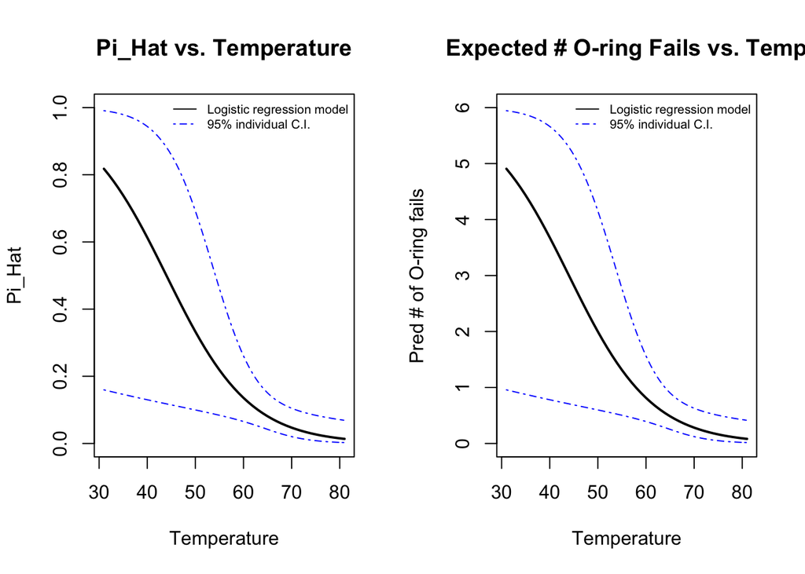

```r
newdf <- data.frame(Temp = seq(from = 31, to = 81, by = 1)) #inputs
pi.hat <- predict(mod.temp, newdata = newdf, type = "response", se.fit = TRUE) #need reponse to have predictions after logit


ci.int <- function(newdata, mod.fit.obj, alpha) { #confidence interval formula for plotting
linear.pred <- predict(object = mod.fit.obj, newdata = newdata,
type = "link", se = TRUE)
CI.lin.pred.lower <- linear.pred$fit - qnorm(p = 1 - alpha/2) *
linear.pred$se
CI.lin.pred.upper <- linear.pred$fit + qnorm(p = 1 - alpha/2) *
linear.pred$se
CI.pi.lower <- exp(CI.lin.pred.lower)/(1 + exp(CI.lin.pred.lower))
CI.pi.upper <- exp(CI.lin.pred.upper)/(1 + exp(CI.lin.pred.upper))
list(lower = CI.pi.lower, upper = CI.pi.upper)
}
par(mfrow=c(1,2))
#Plot for estimated probability of failure vs temperature
plot(newdf$Temp, pi.hat$fit,
     ylim = range(c(0,1)),
     xlab = "Temperature", ylab = "Pi_Hat",
     main = "Pi_Hat vs. Temperature",
     type = 'l',
     col = 'black',
     lwd = 2)

curve(expr = ci.int(newdata = data.frame(Temp = x), mod.fit.obj = mod.temp, alpha = 0.05)$lower,
      col = "blue",
      lty = "dotdash",
      add = TRUE,
      xlim = c(31, 81))

curve(expr = ci.int(newdata = data.frame(Temp = x), mod.fit.obj = mod.temp, alpha = 0.05)$upper,
      col = "blue",
      lty = "dotdash",
      add = TRUE,
      xlim = c(31, 81))

legend("topright", legend = c("Logistic regression model", "95% individual C.I."),
       lty = c("solid", "dotdash"),
       col = c("black", "blue"),
       bty = "n",
       cex = 0.65)

#expected number of failures vs. Temp
plot(newdf$Temp, pi.hat$fit * 6,
     ylim = range(c(0,6)),
     xlab = "Temperature",
     ylab = "Pred # of O-ring fails",
     main = "Expected # O-ring Fails vs. Temp",
     type = 'l',
     col = 'black',
     lwd = 2)
curve(expr = (ci.int(newdata = data.frame(Temp = x), mod.fit.obj = mod.temp, alpha = 0.05)$lower)*6,
      col = "blue",
      lty = "dotdash",
      add = TRUE,
      xlim = c(31, 81))

curve(expr = (ci.int(newdata = data.frame(Temp = x), mod.fit.obj = mod.temp, alpha = 0.05)$upper)*6,
      col = "blue",
      lty = "dotdash",
      add = TRUE,
      xlim = c(31, 81))
legend("topright", legend = c("Logistic regression model", "95% individual C.I."),
       lty = c("solid", "dotdash"),
       col = c("black", "blue"),
       bty = "n",
       cex = 0.65)
```

From the plots above we can see that the probability of O-ring failure increases as temperature decreases. However, we can also see that the confidence interval bands are much wider at lower temperatures than at higher temperatures. This shift occurs at around 60°F. This is likely because we had very few low temperature observations in our sample, 20 of the 23 launches in our sample occurred at temperatures greater than 60°F.

We know that the temperature was 31°F at launch for the Challenger in 1986. When we use our model to estimate the probability of an O-ring failure using this temperature,we find that there is a predicted 82% probability of O-ring failure, with a Wald 95% confidence interval of 15.96% to 99.06%. This is a very large CI band, which in part maybe due to the fact that the Wald CI does not work well with samples of less than 40, and our sample only has 23 observations. However, when we re-calculated the CI using the Profile Likelihood method to account for this we still found the confidence band to be quite large (14.18% to 99.05%).

```r
prediction <- exp(mod.temp$coefficients[1] + mod.temp$coefficients[2]*31)/ (1 + exp(mod.temp$coefficients[1] + mod.temp$coefficients[2]*31))
print(prediction)
```

```
## (Intercept)
##   0.8177744
```

```r
#Wald CI
ci.int(newdata = data.frame(Temp = 31), mod.fit.obj = mod.temp, alpha = 0.05)
```

```
## $lower
##         1
## 0.1596025
##
## $upper
##         1
## 0.9906582
```

```r
#Profile
K <- matrix(data = c(1,31), nrow = 1, ncol = 2)
mod.temp.combo <- mcprofile(object = mod.temp, CM = K)
ci.logit.profile <- confint(object = mod.temp.combo, level = 0.95)
prof_ci <- exp(ci.logit.profile$confint)/(1 + exp(ci.logit.profile$confint))
prof_ci
```

```
##       lower     upper
## 1 0.1418508 0.9905217
```

## Bootstrap Confidence Intervals

```r
simulations <- function(data, R, temp){
  results <- data.frame(temperature = numeric(0), estimates = numeric(0), lower_ci = numeric(0), upper_ci = numeric(0))
  models <- list()
    for (i in 1:R){
      # Simulate dataset with only necessary variables and with replacement
      sim_data <- data[sample(nrow(data), replace = TRUE), -c(1,3)]
      # Estimate model for each dataset
      model <- glm(O.ring/Number ~ Temp, data = sim_data,
                   family = binomial(link = "logit"),
              weights=Number)
      models[[i]] <- model
    }


  for (t in temp){
    estimates <- list()
    j = 1
    for (model in models){
      estimation <- predict(model, newdata = data.frame(Temp = t),
                            type = "response", se.fit = TRUE)$fit
      estimates[[j]] <- estimation
      j <- j + 1
    }
    mean_estimate <- mean(unlist(estimates))
    lower_ci <- quantile(unlist(estimates), 0.05)
    upper_ci <- quantile(unlist(estimates), 0.95)

    results <- rbind(results, data.frame(temperature = t, estimates = mean_estimate,
                                         lower_ci = lower_ci, upper_ci = upper_ci))
  }
  return(results)
}

simulations <- simulations(data, 1000, seq(10, 100, by = 1))
```

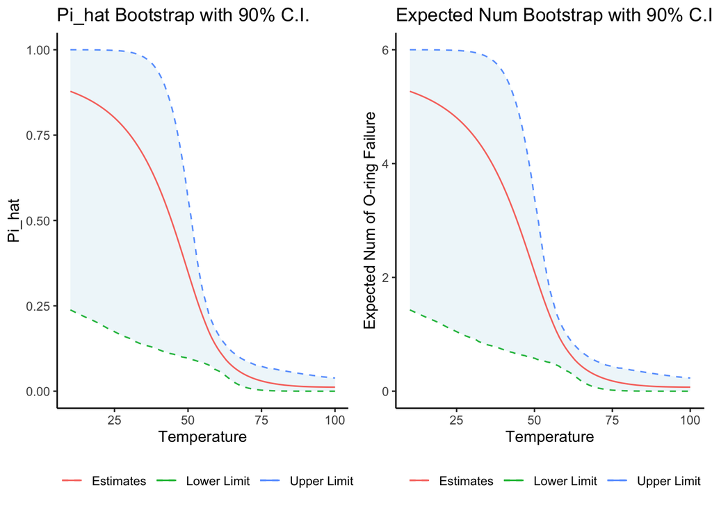

```r
boot_pihat<- ggplot(data = simulations, aes(x = temperature)) +
  geom_line(aes(y = lower_ci, color = "Lower Limit"), linetype =  2, size = 0.5) +
  geom_line(aes(y = upper_ci, color = "Upper Limit"), linetype =  2, size = 0.5) +
  geom_ribbon(aes(ymin = lower_ci, ymax = upper_ci), fill = "lightblue", alpha = .2) +
  geom_line(aes(y = estimates, color = "Estimates"))+
  ggtitle("Pi_hat Bootstrap with 90% C.I.") +
  xlab("Temperature") +
  ylab("Pi_hat") +
  theme_classic()+
  theme(legend.position="bottom", legend.box = "horizontal",legend.title = element_blank())

boot_expec <- ggplot(data = simulations, aes(x = temperature)) +
  geom_line(aes(y = lower_ci*6, color = "Lower Limit"), linetype =  2, size = 0.5) +
  geom_line(aes(y = upper_ci*6, color = "Upper Limit"), linetype =  2, size = 0.5) +
  geom_ribbon(aes(ymin = lower_ci*6, ymax = upper_ci*6), fill = "lightblue", alpha = .2) +
  geom_line(aes(y = estimates*6, color = "Estimates"))+
  ggtitle("Expected Num Bootstrap with 90% C.I.") +
  xlab("Temperature") +
  ylab("Expected Num of O-ring Failure") +
  theme_classic()+
  theme(legend.position="bottom", legend.box = "horizontal",legend.title = element_blank())

grid.arrange(boot_pihat, boot_expec, ncol=2, nrow=1)
```

## Alternative Specification

As a final analysis of our model, we decided to compare it to a linear regression model with the same explanatory variables, this model takes the form $P(Oring.failures) = \beta_{0} +\beta_{1}(temperature)$.

```r
mod.linear <- lm(formula = O.ring/Number ~ Temp, data = data, weights = Number)
stargazer(mod.linear, header=FALSE, type='latex',
          title = "Table 4",
          covariate.labels = c("Temperature (F)"),
          column.labels = c("Linear"),
          dep.var.caption  = "",
          dep.var.labels = "O-ring Failure",
          no.space = TRUE)
```

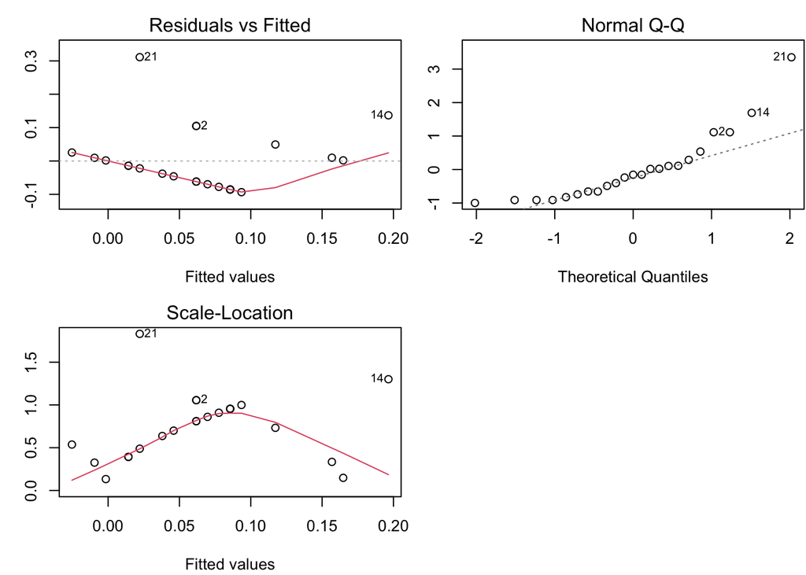

```r
par(mfrow=c(2,2), mar=c(4.1,3.1,2.1,0.1))
plot(mod.linear, which = c(1,2,3))
```

Following this interpretation we can see one immediate problem with this the assumption that the model of the relationship between `Temp` and the probability of O-ring failure is linear. The probability of failure is by definition bounded by [0,1], so a linear model, which is unbounded is not an appropriate model choice. We can see this since, with our calculated model, at temperatures greater than 77.97°F we get a predicted probability of less than 0, and at temperatures less than -48.415°F we get a predicted probability of failure of greater than 1.

In addition to this, when we evaluate the other assumptions needed to create a linear regression model through plotting the residuals, we can see that several other assumptions are violated. First, the samples used to create the model must be IID, this assumption is possibly violated since the O-rings are not necessary independent as each set of 6 O-rings on a launch are subjected to the same conditions and the failure of 1 O-ring might influence the state of the other O-rings. In addition when we plotted the residuals vs fitted values plot for the model we can see that the assumption of zero-conditional mean of residuals is violated, if the assumption were met we would see a linear relationship between the two, but from the plot we can see the non-linear relationship. When we look at the Scale-Location plot we can also see that the assumption of the homoskedasticity of the errors is also violated. The plotted residuals are not equally spread across the range of predictors. Lastly, from the Q-Q plot we can see that our model has a relatively normal distribution of its residuals, but that it is not as normal towards the upper quantiles, with a larger sample we may have been able to assume the Central Limit Theorem but with such a small sample we unable to do so with confidence. The only assumption that holds true is that of no perfect co-linearity. Since our model only includes one predictors, we know that there is no co-linearity.

# Conclusions

```r
beta.hat <- mod.temp$coefficients
temperature <- seq(from = 30, to= 80, by = 10)
K <- cbind(1, temperature)
linear.combo <- mcprofile(object = mod.temp, CM = K)
ci.log.OR <- confint(object = linear.combo, level = 0.95, adjust = 'none')
data.frame(temperature, OR.hat = round(1/exp(ci.log.OR$estimate), 2),
           OR.low = round(1/exp(ci.log.OR$confint$upper), 2), OR.up = round(1/exp(ci.log.OR$confint$lower), 2))
```

```
##    temperature Estimate OR.low  OR.up
## C1          30     0.20   0.01   5.89
## C2          40     0.63   0.06   7.71
## C3          50     2.00   0.48  10.36
## C4          60     6.37   3.00  15.66
## C5          70    20.23   9.51  55.47
## C6          80    64.27  15.67 398.15
```

```r
beta.ci<-confint(object = mod.temp, parm = "Temp", level = 0.95)
rev(exp(-10*beta.ci))  # Invert C.I. for OR with c = 10, ignore limit labels
```

```
##   97.5 %    2.5 %
## 1.277239 8.350003
```

```r
exp(-10*mod.temp$coefficients[2]) #OR with -10 tempreature
```

```
##     Temp
## 3.177236
```

Our final model found that for every 1 degree increase in temperature the probability of O-ring failure decreases by 11%. Another way of looking at these results is that for a 10 degree decrease in the temperature the estimated odds that an o-ring fails changes by 3.177 times, with a 95% Confidence Interval the odds of an O-ring failure change between 1.277 and 8.35 times for every 10 unit decrease in temperature.

These results confirm what the authors intial analysis founds, that at lower temperatures there is a higher likelihood of O-ring failure. Based on these results, it is likely that the low temperatures the day of the challenger launch contributed to the ultimately catastrophic O-ring failures.